# Tutorial on Bayesian Graphical Modeling

Author

Maarten Marsman

Published

January 28, 2026

# 🧭 Recap and Session Setup

In the lecture, we explored how **Bayesian reasoning** helps distinguish *evidence of absence* from *absence of evidence*—showing how Bayes factors quantify support for or against network connections.

Now, in the tutorial, we’ll put these ideas into practice. You’ll learn how to estimate Bayesian network models in **R** and **JASP**, interpret edge evidence, and understand how prior assumptions and uncertainty shape your conclusions.

## 🎯 Learning Outcomes

By the end of this session, you will be able to:

- Fit network models using `easybgm` or `JASP`
- Use **Bayes factors** to test edge inclusion and interpret their strength
- Visualize network estimates and uncertainty clearly
- Examine the influence of **prior assumptions** on network conclusions

## 📘 This Session

**Recommended Reading:**

- Huth, K., de Ron, J., Goudriaan, A., Luigjes, J., Mohammadi, R., van Holst, R., Wagenmakers, E.-J., & Marsman, M. (2023). Bayesian Analysis of Cross-Sectional Networks: A Tutorial in R and JASP. *Advances in Methods and Practices in Psychological Science*, *6*, 1-18. doi: 10.1177/25152459231193334
- Huth, K., Keetelaar, S., Sekulovski, N., van den Bergh, D., & Marsman, M. (2024). Simplifying Bayesian Analysis of Graphical Models for the Social Sciences With easybgm: A User-Friendly R-Package. *Advances .in/psychology*, *e66366*. doi: 10.56296/aip00010/

**Optional Reading**

- Sekulovski, N., Keetelaar, S., Huth, K., Wagenmakers, E.-J., van Bork, R., van den Bergh, D., & Marsman, M. (2024). Testing Conditional Independence in Psychometric Networks: An Analysis of Three Bayesian Methods. *Multivariate Behavioral Research*, *59*, 913-933. doi: 10.1080/00273171.2024.2345915

**R Setup Tip:** Make sure to install and load the following libraries before running the examples:

```r
library(easybgm)
library(BDgraph)
library(bgms)
```

Before we dive into the hands-on part, let’s briefly revisit what we covered in Part I and why it matters for what we’re about to do.

## 🔍 Two fundamental questions

In network analysis, we ask two key questions:

1️⃣ **Is there an effect?** (edge inclusion)  
2️⃣ **What is the effect?** (edge strength and sign)

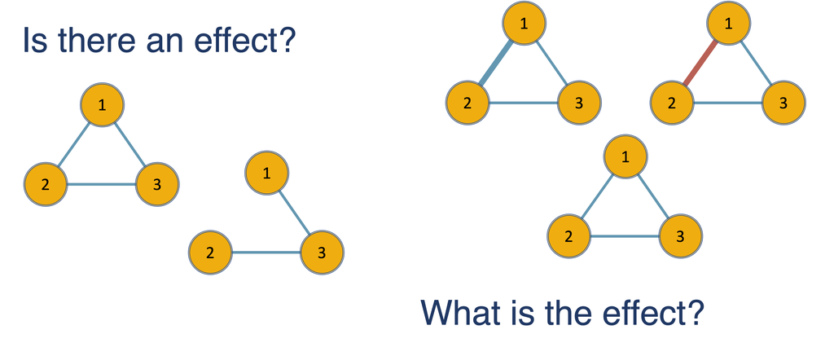

> In Part I, we focused on Question 1 — *testing whether an edge exists*.  
> In this tutorial, we’ll also explore Question 2 — *estimating how strong and positive/negative that edge is.*

### 💡 Evidence vs. absence

Network estimation alone cannot tell us why an edge is missing —  
is it truly absent, or do we simply lack information?

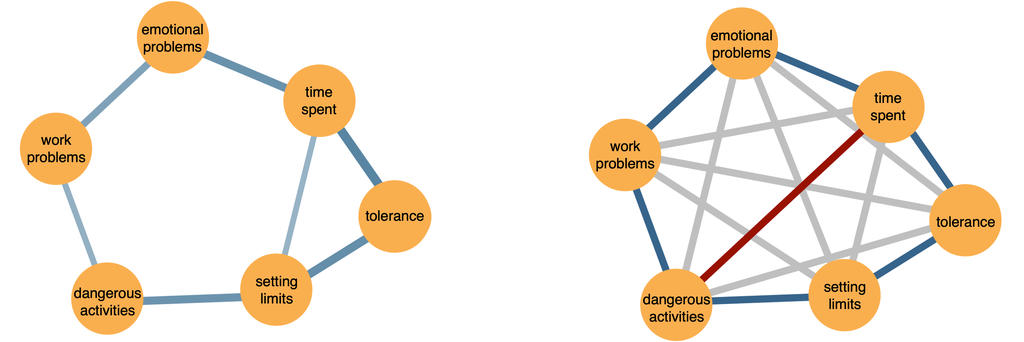

> The Bayesian approach helps us distinguish between  
> **absence of evidence** and **evidence of absence** using Bayes factors.

### 📊 From priors to posteriors

We assign **prior probabilities** to possible network structures,  
then update them with data using **Bayes’ Rule**.

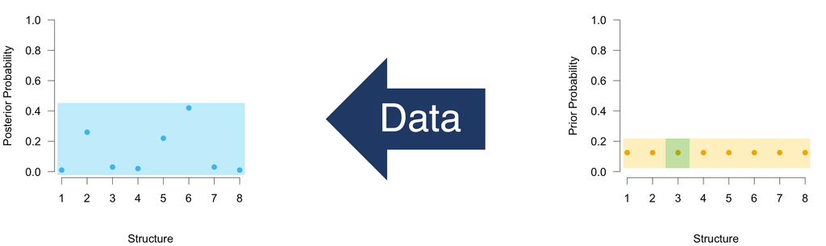

> A posterior probability expresses how plausible each structure is *after* seeing the data.

### 🧠 Quick quiz

Try to recall:

1. What does a Bayes factor compare?
2. What does a value of $\text{BF}_{10} = 10$ mean?
3. Why is it important to separate *absence of evidence* from *evidence of absence*?

*(Discuss with your neighbor or write down your answers before we move on!)*

Next, we’ll apply all this in practice — estimating and interpreting Bayesian network models using **easybgm** and **JASP**.